# Fall 2019 Lab Rotation Simulation

Jiayi (Jessie) Tong

10/13/2019

### Aim of this file

This R markdown file is written to simulate the single-cell data to demonstrate if the order of the batch when applying mutual nearest neighbors (MNN) would affect the clustering results.

### Simulation Design

In this simulation study, we are going to simulate four different batches to mimic the temporal from week 0 to week 24. As time goes on, the observed cell population increases. In Figure 1, we present the idea of the simulated data. In each batch, there are different numbers of cell populations: 3, 4, 5, and 7. There exist batch effects among the cell populations 1, 2, 3, 4 and 5 across four batches.

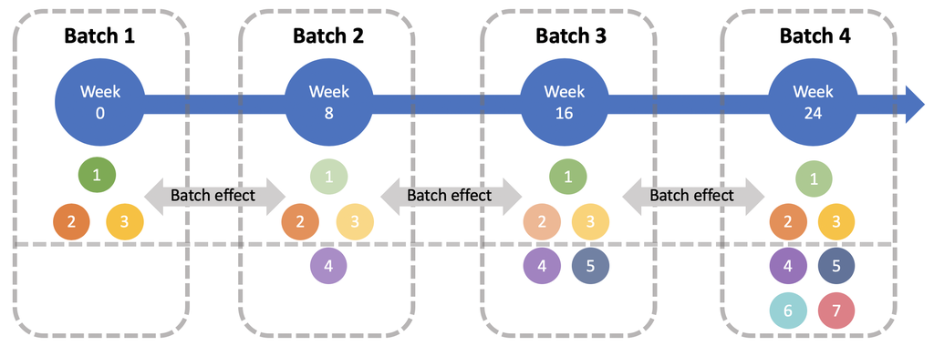

Figure 1

### R package to be used: Symsim

To simulate the data, we are going to use Symsim package, which is one most recently published R package for simulating multiple faceted variability in single cell RND sequencing data.

```r
# Install SymSim
library("devtools")
# devtools::install_github('YosefLab/SymSim')
```

#### 0. Original

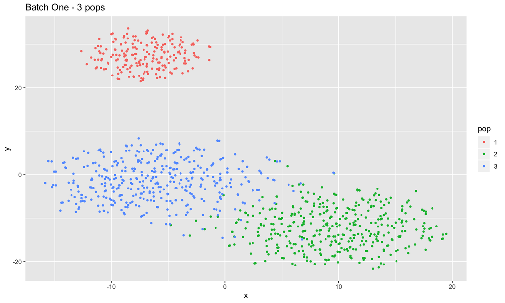

```r
library("SymSim")
ngenes = 2000
# number of gene for each cell is 2000 (based on last discussion
# we would like to set this to 20,000.
# To decrease the computational time, I set the number to 2000 as for now.)
true_counts_res <- SimulateTrueCounts(ncells_total=1000, # total number of cells
                                      min_popsize=200, # size of the smallest pop
                                      i_minpop=1, # specify which pop is smallest
                                      ngenes=ngenes, # number of genes
                                      nevf=10, # number of EVFs for each kinetic parameter
                                      evf_type="discrete", # sub-population
                                      n_de_evf=9, # number of differential evfs between populations for one kinetic parameter
                                      scale_s = 0.2, # the cell size parameter
                                      vary="s", # which kinetic parameters have differential evfs
                                      Sigma=0.5, # the smaller, the higher the hetero
                                      phyla=Phyla3(), # tree to define relationship between populations
                                      randseed=0)
tsne_true_counts <- PlotTsne(meta=true_counts_res[[3]], data=log2(true_counts_res[[1]]+1), evf_type="discrete", n_pc=20, label='pop', saving = F, plotname="Batch One - 3 pops")
tsne_true_counts[[2]]
```

#### 1. Different scale_s: the cell size parameter

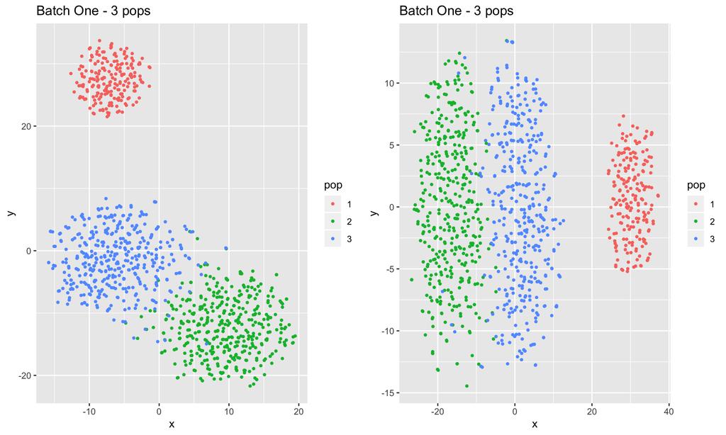

```r
true_counts_res <- SimulateTrueCounts(ncells_total=1000,
                                      min_popsize=200,
                                      i_minpop=1,
                                      ngenes=ngenes,
                                      nevf=10,
                                      evf_type="discrete",
                                      n_de_evf=9,
                                      scale_s = 0.8, #!!!!!!! change here
                                      vary="s",
                                      Sigma=0.5,
                                      phyla=Phyla3(),
                                      randseed=0)
tsne_true_counts_1 <- PlotTsne(meta=true_counts_res[[3]], data=log2(true_counts_res[[1]]+1), evf_type="discrete", n_pc=20, label='pop', saving = F, plotname="Batch One - 3 pops")
grid.arrange(tsne_true_counts[[2]],
             tsne_true_counts_1[[2]],
             ncol=2, nrow = 1)
```

$\color{red}{\text{1. How to specify three different proportions of three different groups?}}$

$\color{red}{\text{2. scale_s is the cell size parameter. I used 0.2 and 0.8 in the above two figures, how to explain this parameter corresponsing to the figures?}}$

#### 2. Different “nevf”: number of EVFs for each kinetic parameter

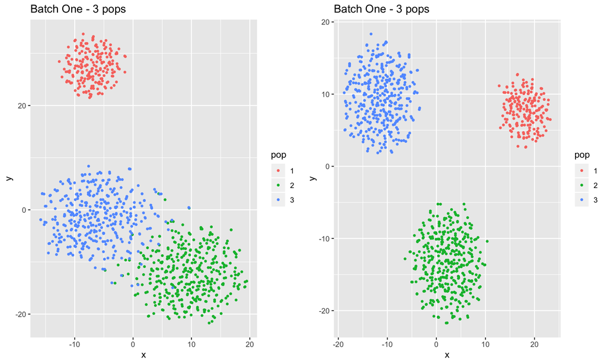

```r
ngenes = 2000
true_counts_res <- SimulateTrueCounts(ncells_total=1000,
                                      min_popsize=200,
                                      i_minpop=1,
                                      ngenes=ngenes,
                                      nevf=20, #!!!!!!! change here
                                      evf_type="discrete",
                                      n_de_evf=9,
                                      scale_s = 0.2,
                                      vary="s",
                                      Sigma=0.5,
                                      phyla=Phyla3(),
                                      randseed=0)
tsne_true_counts_2 <- PlotTsne(meta=true_counts_res[[3]], data=log2(true_counts_res[[1]]+1), evf_type="discrete", n_pc=20, label='pop', saving = F, plotname="Batch One - 3 pops")
grid.arrange(tsne_true_counts[[2]],
             tsne_true_counts_2[[2]],
             ncol=2, nrow = 1)
```

#### 3. Different “n_de_evf”: number of differential evfs between populations for one kinetic parameter

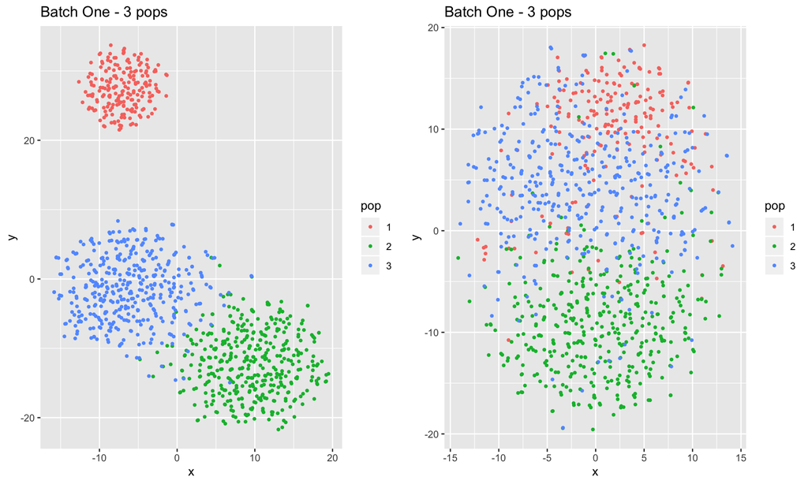

```r
ngenes = 2000
true_counts_res <- SimulateTrueCounts(ncells_total=1000,
                                      min_popsize=200,
                                      i_minpop=1,
                                      ngenes=ngenes,
                                      nevf=10,
                                      evf_type="discrete",
                                      n_de_evf=4, #!!!!!!! change here
                                      scale_s = 0.2,
                                      vary="s",
                                      Sigma=0.5,
                                      phyla=Phyla3(),
                                      randseed=0)
tsne_true_counts_3 <- PlotTsne(meta=true_counts_res[[3]], data=log2(true_counts_res[[1]]+1), evf_type="discrete", n_pc=20, label='pop', saving = F, plotname="Batch One - 3 pops")
grid.arrange(tsne_true_counts[[2]],
             tsne_true_counts_3[[2]],
             ncol=2, nrow = 1)
```

#### 4. Different “vary”: which kinetic parameters have differential evfs

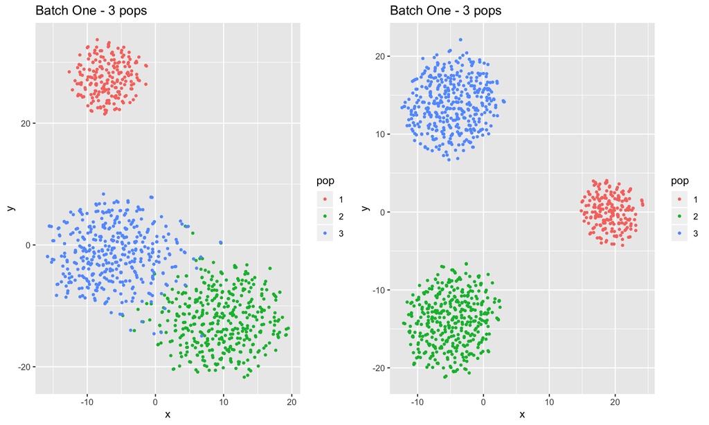

```r
ngenes = 2000
true_counts_res <- SimulateTrueCounts(ncells_total=1000,
                                      min_popsize=200,
                                      i_minpop=1,
                                      ngenes=ngenes,
                                      nevf=10,
                                      evf_type="discrete",
                                      n_de_evf=9,
                                      scale_s = 0.2,
                                      vary="all", #!!!!!!! change here
                                      Sigma=0.5,
                                      phyla=Phyla3(),
                                      randseed=0)
tsne_true_counts_4 <- PlotTsne(meta=true_counts_res[[3]], data=log2(true_counts_res[[1]]+1), evf_type="discrete", n_pc=20, label='pop', saving = F, plotname="Batch One - 3 pops")
grid.arrange(tsne_true_counts[[2]],
             tsne_true_counts_4[[2]],
             ncol=2, nrow = 1)
```

#### 5. Different number of population: Phyla3() -> Phyla4()

```r
ngenes = 2000
true_counts_res <- SimulateTrueCounts(ncells_total=1000,
                                      min_popsize=200,
                                      i_minpop=1,
                                      ngenes=ngenes,
                                      nevf=10,
                                      evf_type="discrete",
                                      n_de_evf=9,
                                      scale_s = 0.2,
                                      vary="s",
                                      Sigma=0.5,
                                      phyla=Phyla4(), #!!!!!!! change here
                                      randseed=0)
```

```
## Error in Phyla4(): could not find function "Phyla4"
```

$\color{red}{\text{3. Phyla4() does not exit when creating an example tree with 4 tips}}$

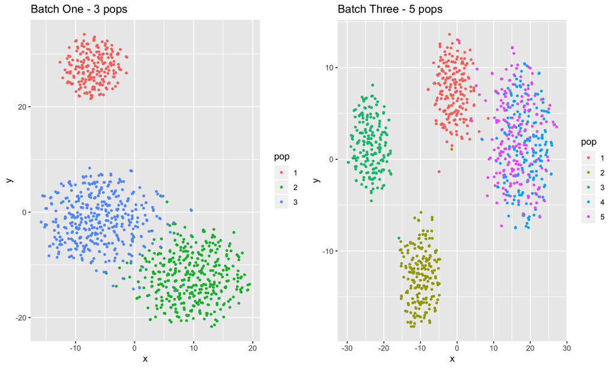

```r
ngenes = 2000
true_counts_res <- SimulateTrueCounts(ncells_total=1000,
                                      min_popsize=200,
                                      i_minpop=1,
                                      ngenes=ngenes,
                                      nevf=10,
                                      evf_type="discrete",
                                      n_de_evf=9,
                                      scale_s = 0.2,
                                      vary="s",
                                      Sigma=0.5,
                                      phyla=Phyla5(), #!!!!!!! change here
                                      randseed=0)
tsne_true_counts_6 <- PlotTsne(meta=true_counts_res[[3]], data=log2(true_counts_res[[1]]+1), evf_type="discrete", n_pc=20, label='pop', saving = F, plotname="Batch Three - 5 pops")
grid.arrange(tsne_true_counts[[2]],
             tsne_true_counts_6[[2]],
             ncol=2, nrow = 1)
```

$\color{red}{\text{4. How to make sure the cells are simulated for the same cell population?}}$

I know that in each Batch, the cell types are controlled by the number of EVFs (i.e., nEVFs) representing dimension of the latent space of cell identify (length of EVF vectors). Values of EVFs are sampled from N($\mu, \sigma^2$) for each subpopulation, where default value of $\mu$ is 1, and $\sigma$ determines the within-population variation. For multiple populations, users input a tree phyla, and the $\mu$ for each population is generated along the tree

### References:

Haghverdi, Laleh, et al. “Batch effects in single-cell RNA-sequencing data are corrected by matching mutual nearest neighbors.” Nature biotechnology 36.5 (2018): 421.

Zhang, Xiuwei, Chenling Xu, and Nir Yosef. “Simulating multiple faceted variability in single cell RNA sequencing.” Nature communications 10.1 (2019): 2611.